# Analisis De Tesis

## Correlaciones de variables numerica vs categorica.

En nuestro caso solo tenemos una variable de tipo numérica o continua por eso solo aremos es análisis de correlación entre una variable de tipo numérica y una variable de tipo categórica para ver si estas tienen un tipo de relación o si no se relacionan.

Las variables que se eligieron son: numérica= Horas_diarias_estudio, categórica= Reprobación. La hipótesis que queremos comprobar es si los estudiantes que han tenido reprobación en sus clases pues le dedican menos horas de estudio al día y si los que no han tenido una reprobación le dedican más horas de estudio al día.

Realizando un pequeño análisis de las variables obtuvimos los siguientes resultados.

```r
str(survey$Reprobaci.n)
```

```
##  Factor w/ 2 levels "No","Si": 2 1 2 2 2 1 2 1 2 1 ...
```

```r
table(survey$Reprobaci.n)
```

```
##
##  No  Si
##  30 100
```

```r
summary(survey$Horas_.diarias_.estudio)
```

```
##    Min. 1st Qu.  Median    Mean 3rd Qu.    Max.
##   1.000   2.000   2.000   2.731   3.000   8.000
```

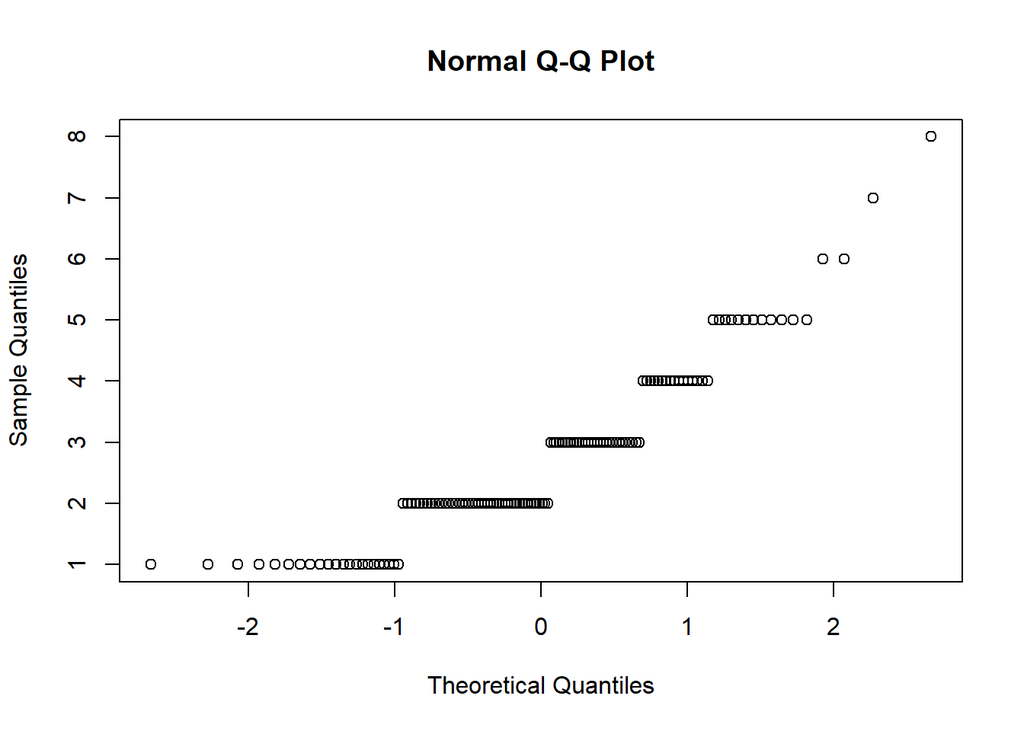

```r
qqnorm(survey$Horas_.diarias_.estudio)
```

La funcion qqline nos mestra de mejor forma que tenemos algunos que podrian generar error o son atipicos

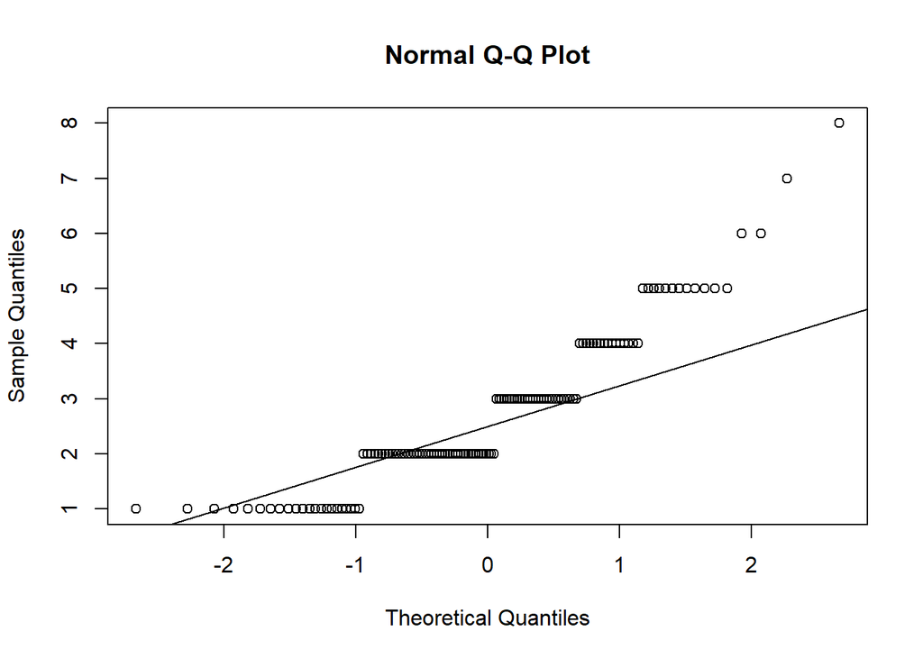

```r
qqnorm(survey$Horas_.diarias_.estudio)
qqline(survey$Horas_.diarias_.estudio)
```

Los resultados de qqline pues corroboran lo indicado anterior mente que los resultados que están entre 5 y 8 pues se alejan de la línea aportando bastante error y una forma más clara de poder ver esto es mediante un boxplot que nos indicara si tenemos o no valores atípicos.

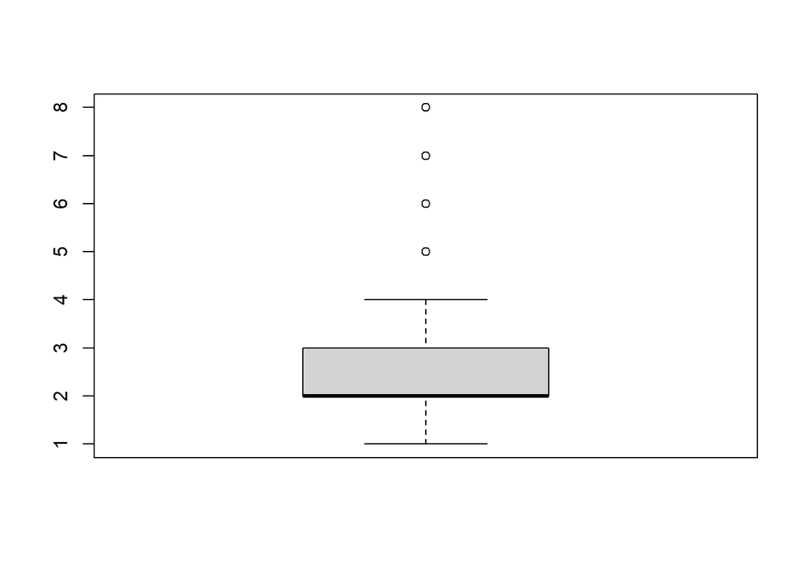

```r
boxplot(survey$Horas_.diarias_.estudio)
```

Los resultados del boxplot pues indican que tenemos varios valores atípicos y son los resultados que están por encima de valores de 4 horas diarias de estudio estos valores atípicos si hacemos un análisis pues nos aportan error. Para esta variable corrimos la prueba de shapiro.test para ver si nuestra variable tiene una distribución normal obteniendo los siguientes resultados.

```r
shapiro.test(survey$Horas_.diarias_.estudio)
```

```
##
##  Shapiro-Wilk normality test
##
## data:  survey$Horas_.diarias_.estudio
## W = 0.8871, p-value = 1.696e-08
```

H_O nuestra variable Horas_diarias_estudio es normal.

H_A nuestra variable es anormal

Regla si nuestro p-value que arroje nuestra prueba de shapiro es mayor a 0.05 no rechazamos nuestra hipótesis nula.

Conclusión: como p-value es menor a 0.05 rechazamos nuestra hipótesis nula.

Esto nos indica que nuestra variable Horas_diarias_estudio de tipo numérica es una variable que no tiene una distribución normal por lo tanto no podríamos seguir haciendo nuestro tratamiento ya que las siguientes pruebas son de tipo paramétrico y estas requieren que nuestra variable tenga una distribución normal.

#### Para fines de estudio

```r
survey[survey$Horas_.diarias_.estudio > 4 , "Horas_.diarias_.estudio"] <- median(survey$Horas_.diarias_.estudio)
```

Después de hacer esta transformación hacemos nuevamente el análisis de nuestra variable Horas_diarias_estudio para ver si logramos la normalidad obteniendo los siguientes resultados.

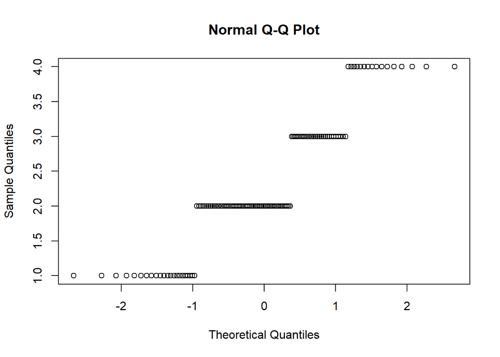

```r
qqnorm(survey$Horas_.diarias_.estudio)
```

Como observamos en nuestro qqnorm pues ahora parecería que nuestra regresión no tendría tanto error como se mostraba al principio esto lo refleja mejor nuestro qqline que muestra los siguientes resultados.

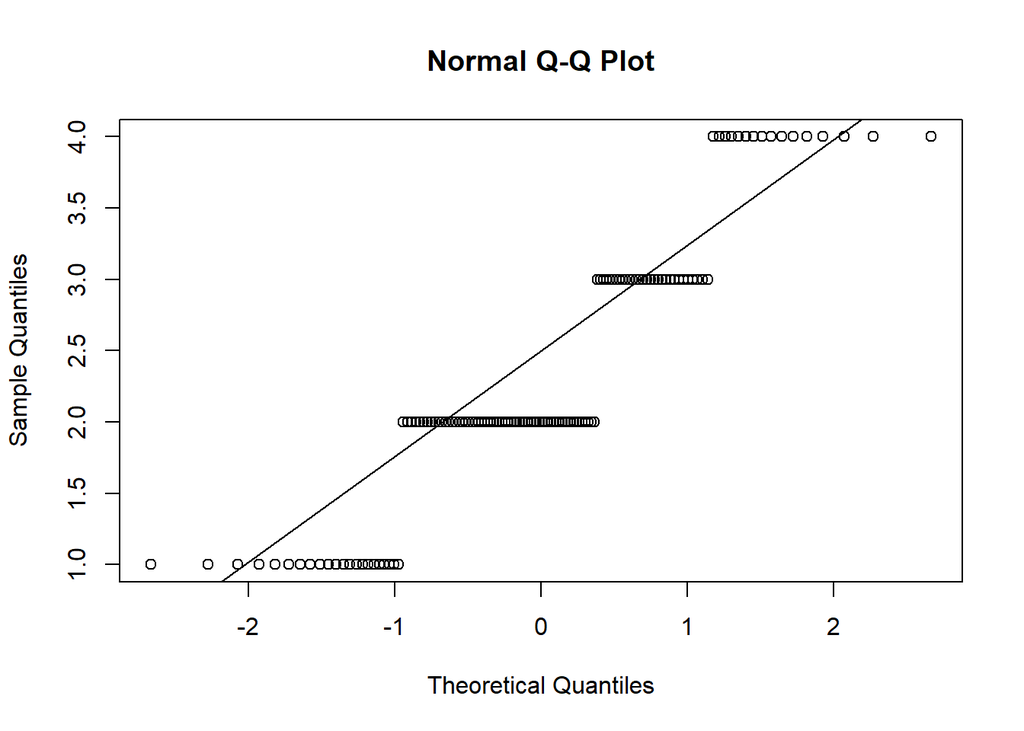

```r
qqnorm(survey$Horas_.diarias_.estudio)
qqline(survey$Horas_.diarias_.estudio)
```

Como podemos notar nuestro qqline refleja que ya no tenemos eso valores que estaban alejados de la línea aparentemente no tendríamos tanto error. Pero para ver de forma más clara si aún tenemos valores atípicos pues corremos nuestro boxplot.

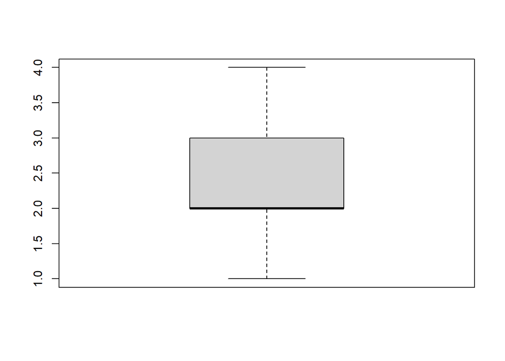

```r
boxplot(survey$Horas_.diarias_.estudio)
```

Como refleja nuestro boxplot ya no tenemos esos valores atípicos que podíamos apreciar al principio también nos indica que la mayoría de encuestados se encuentra en nuestro segundo cuartil que se posiciona en 2 horas diarias de estudio, pero para corroborar si nuestra variable ahora si tiene una distribución normal volvemos a realizar nuestra prueba de shapiro obteniendo los siguientes resultados.

```r
shapiro.test(survey$Horas_.diarias_.estudio)
```

```
##
##  Shapiro-Wilk normality test
##
## data:  survey$Horas_.diarias_.estudio
## W = 0.85877, p-value = 8.527e-10
```

H_O nuestra variable Horas_diarias_estudio es normal.

H_A nuestra variable no es anormal.

Como vemos nuestra prueba de shapiro volvió a indicar que nuestra variable es anormal por lo que no podemos seguir realizando las pruebas de tipo paramétrico porque no tenemos una distribución normal en nuestra variable Horas_diarias_estudio.

Ya que no podemos hacer las conclusiones que planteamos al principio de saber si los estudiantes que si han tenido reprobación de clases tienen un número menor de horas de estudio contra los que no han reprobado clases.

En cuanto a correlación de variables numéricas no se logró hacer el análisis debido a que en nuestra encuesta solo posee una variable de tipo numérica que en este caso es Horas_diaras_estudio para ello hicimos un str de nuestro survey que demuestra la existencia de solo una variable numérica.

```r
str(survey)
```

```
## 'data.frame':    130 obs. of  42 variables:
##  $ Marca_temporal           : Factor w/ 129 levels "2020/04/04 5:19:57 p.?m. GMT-6",..: 1 2 3 4 13 14 15 16 17 18 ...
##  $ Edad                     : Factor w/ 5 levels ">38","18-22",..: 3 4 3 3 3 3 3 4 3 3 ...
##  $ Genero                   : Factor w/ 2 levels "Femenino","Masculino": 1 2 1 1 2 1 2 2 2 2 ...
##  $ Procedencia              : Factor w/ 2 levels "No","Si": 1 1 2 2 1 2 1 2 2 2 ...
##  $ Traslado_.UNAH           : Factor w/ 3 levels "Muchas","Normal",..: 2 2 2 2 2 2 3 3 3 2 ...
##  $ Computadora_.permanente  : Factor w/ 2 levels "No","Si": 2 2 2 2 2 2 2 2 2 2 ...
##  $ Conexi.n_.permanente     : Factor w/ 2 levels "No","Si": 1 2 2 2 2 2 2 2 2 2 ...
##  $ Calidad_.conexi.n        : Factor w/ 3 levels "","No","Si": 1 3 3 3 3 2 3 3 2 3 ...
##  $ Estudio_.secundaria      : Factor w/ 2 levels "No","Si": 1 2 1 1 1 1 1 1 1 1 ...
##  $ Cantidad_.carreras       : Factor w/ 2 levels "No","Si": 1 1 1 1 1 1 1 1 1 1 ...
##  $ Rango_.acad.mico         : Factor w/ 4 levels "<70","70-79",..: 2 4 3 3 3 4 2 4 2 3 ...
##  $ Mejorar_..ndice          : Factor w/ 8 levels "Flexibilidad de horarios",..: 3 3 3 5 1 2 8 1 4 1 ...
##  $ Exelencia_academica      : Factor w/ 2 levels "No","Si": 1 2 2 2 2 2 1 2 1 2 ...
##  $ Reprobaci.n              : Factor w/ 2 levels "No","Si": 2 1 2 2 2 1 2 1 2 1 ...
```

[output cut: 28 more lines]

## Analisis Explicativo

### Definicion de variable de respuesta

La variable de respuesta que identificamos es Uso_LMS la cual utilizaremos para hacer una regresión logística con el objetivo de identificar aquel grupo de estudiantes que hicieron mención a que no han usado este tipo de plataformas lo cual nos indicaría que nuestra propuesta de usar un LMS para influir en el rendimiento del estudiante, correría riesgo de no funcionar ya que este grupo indica que no ha usado esta tecnología o desconoce el concepto.

### Aplicacion de regresion logistica

Como mencionamos anteriormente es de sumo interés identificar el grupo de estudiantes que indican que no han usado una plataforma LMS cuyo porcentaje es 23.84% para lo cual aplicaremos una regresión logística de la variable de respuesta junto con un conjunto de variables que consideramos tienen relación o que influyen con ella.

```
##
## No Si
## 31 99
```

```
##
##        No        Si
## 0.2384615 0.7615385
```

El conjunto de variables que elegimos es el siguiente:

1. Computadora_.permanente
2. Conexión_.permanente
3. Rango_.promedio_.clases
4. Horas_.diarias_.estudio
5. Disciplina
6. Autodidacta
7. Plataforma
8. Frecuencia_.de_.uso
9. Recursos.

Los resultados que obtuvimos en la regresión logística son los siguientes

```
##
## Call:  glm(formula = Uso_.lms ~ ., family = "binomial", data = set)
##
## Coefficients:
##                           (Intercept)              Computadora_.permanenteSi
##                               14.5912                                 0.9428
##          Rango_.promedio_.clases2 a 4          Rango_.promedio_.clases4 a 6
##                                1.0038                                 0.6979
##               Horas_.diarias_.estudio                           DisciplinaNo
##                               -0.1043                               -17.7607
##                          DisciplinaSi                          AutodidactaSi
##                               -0.8006                                 0.7112
##                            RecursosSi                           PlataformaSi
##                                0.7208                               -15.4524
## Frecuencia_.de_.usoMuy frecuentemente               Frecuencia_.de_.usoNunca
##                               -0.1330                                 0.7413
##
## Degrees of Freedom: 129 Total (i.e. Null);  118 Residual
## Null Deviance:       142.8
## Residual Deviance: 129.6     AIC: 153.6
```

La regresión logística nos muestra los coeficientes de cada variable que nos pueden ayudar a predecir el comportamiento de un nuevo registro.

Utilizando la función varImp() nos permite ordenar las variables en su grado de importancia el resultado se aprecia en la siguiente imagen.

```
##                                           Overall
## Computadora_.permanenteSi             1.166324206
## Rango_.promedio_.clases2 a 4          1.058451226
## Rango_.promedio_.clases4 a 6          0.720547900
## Horas_.diarias_.estudio               0.647031548
## DisciplinaNo                          0.007401679
## DisciplinaSi                          1.312439482
## AutodidactaSi                         0.879565018
## RecursosSi                            0.907151420
## PlataformaSi                          0.010015674
## Frecuencia_.de_.usoMuy frecuentemente 0.253704630
## Frecuencia_.de_.usoNunca              0.663251120
```

Según el resultado de esta función ordena las variables de acuerdo al grado de importancia y nos indica que una de las variables que tiene mayor importancia es Computadora_permanente.

Posteriormente cuando hacemos el arrange de nuestro coeficiente overall nos ordena las variables más importantes que influyen en este proceso. Los resultados de nuestro arrange los podemos apreciar acontinuacion.

```
##        Overall                                   col
## 1  1.312439482                          DisciplinaSi
## 2  1.166324206             Computadora_.permanenteSi
## 3  1.058451226          Rango_.promedio_.clases2 a 4
## 4  0.907151420                            RecursosSi
## 5  0.879565018                         AutodidactaSi
## 6  0.720547900         Rango_.promedio_.clases4 a 6
## 7  0.663251120              Frecuencia_.de_.usoNunca
## 8  0.647031548               Horas_.diarias_.estudio
## 9  0.253704630 Frecuencia_.de_.usoMuy frecuentemente
## 10 0.010015674                          PlataformaSi
## 11 0.007401679                          DisciplinaNo
```

Una vez que ya tenemos nuestras variables ordenadas según la importancia que tienen respecto a nuestra variable de peso pues evaluaremos algunas de ellas para ver si hace sentido la interpretación con respecto a la gráfica, correlación entre la variable Disciplina y Uso_lms se presenta la siguiente gráfica.

[figure not shown]

Como lo indica el grafico aquellos estudiantes que mencionaron que no son disciplinados pues son los que tienen más riesgo que a la hora de implementarles una plataforma de LMS pues no incida en su rendimiento ya que no tienen una buena práctica de cumplir con sus deberes como estudiante.

#### Correlación de variable Computadora_permanente vs Uso_lms

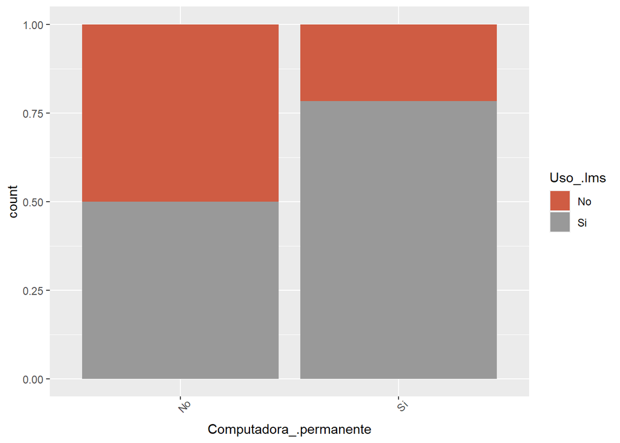

La grafica nos indica que tenemos que poner más atención a aquellos estudiantes que indican que no tiene computadora permanente ya ellos no tendrían las herramientas necesarias para el uso de una plataforma LMS que influya en su rendimiento.

### Correlación Recursos vs Uso_lms

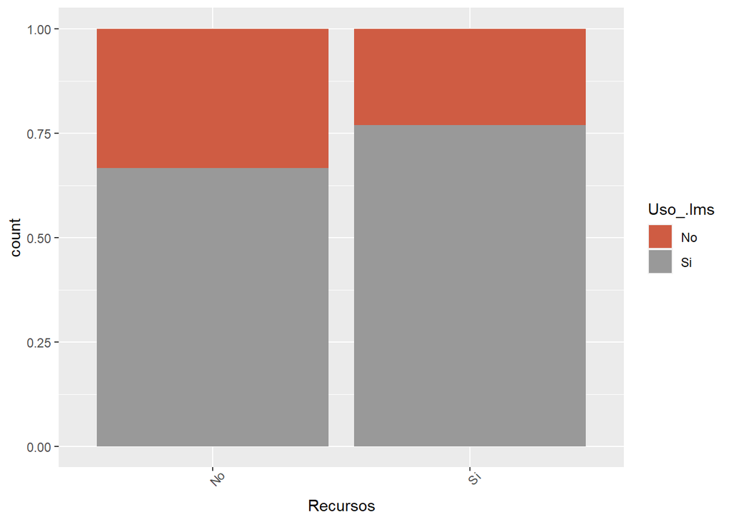

La grafica nos indica que aquellos que consideran que un aumento de los recursos tanto de infraestructura como de personal no ayudaría a mejorar el rendimiento académico son los que tienen más riesgo de no poder mejorar su rendimiento mediante el uso de una plataforma LMS.

### Correlación Rango_promedio_clases vs Uso_lms

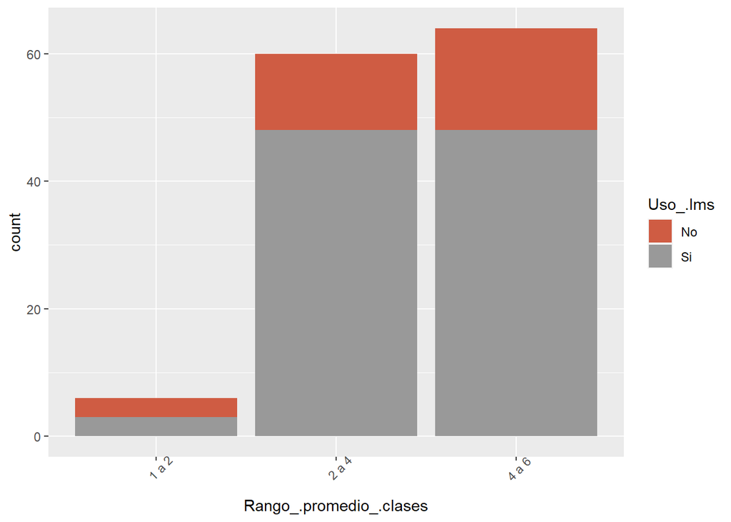